# Lab 07 Prelab: Introduction to Resistor-Capacitor circuits and a review of chi-squared ($\chi^2$)

```python
import data_entry2
import matplotlib.pyplot as plt
import numpy as np
```

**Please note:** *Lab 07 is a participation-based lab that focuses on getting you to practice interacting with an oscilloscope, which is a device that measures and graphs voltage as a function of time. Developing some initial proficiency with the oscilloscope is one of the primary learning goals for this lab. As such, this lab will not use a criterion-based rubric and will instead focus on providing feedback on things that your group is doing well and things that could be improved.*

This document reviews the physics behind Lab 07 (RC Circuits, Part 1), and guides you through the measurements needed to determine the time constant of the voltage decay from a discharging capacitor. You will then explore the effect of changing resistance on the voltage decay. Finally, you will build your spreadsheet and uncertainty propagation code for a single measurement of the time constant from a simulated voltage decay provided in this notebook.

**NOTE**: *the voltage decay curve in this prelab is simulated from a capacitor that is different than the actual capacitor you will use in your circuit during the labs. Therefore, while the spreadsheet format and uncertainty propagation code can be copied from this prelab to your lab notebook, you will need to take new data during the lab to enter into your spreadsheet and run through your uncertainty propagation code.*

During this lab you will build a scatter plot to show how the time constant is related to the size of the resistor used in the circuit, allowing us to determine the capacitance of the capacitor in the circuit.

## The physics of RC (Resistor-Capacitor) circuits

### The capacitor

The parallel-plate capacitor is the simplest example of a capacitor. Here we bring two conducting surfaces (plates) close to each other and allow the plates to become oppositely charged due to an external voltage source. The power source will cause one plate to become positively charged and the other negatively charged. This difference in charge on the two surfaces will create an electric field between them, which in turn produces a voltage difference between the two surfaces. If the power supply has been turned on for long enough, this voltage will exactly match that of the power source, as the system will reach a state of equilibrium.

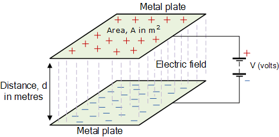

The ratio of the charge ($Q$) on the conductors to the voltage difference between the conductors ($V_C$) is known as the capacitance ($C$),

$$ C = \frac{Q}{V_C} = \frac{\text{ratio of the charge on the conductors}}{\text{voltage difference between the conductors}} $$

This is a *characteristic* quantity of the capacitor, which is proportional to the area of the conductors and inversely proportional to the distance between them.

### Discharging a capacitor

A common practical use for a capacitor is that of a power supply that can be quickly charged or discharged. An interesting consequence of the relationship between capacitor voltage ($V_C$) and stored charge ($Q$) is that it cannot supply a steady voltage to a circuit when used as a power supply.

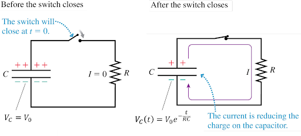

The image above shows a capacitor, charged to a voltage of $V_0$. We put this in a circuit which also contains a resistor. When we complete the circuit by closing the switch, current (moving charge) starts to flow in the circuit and this current flowing from the capacitor reduces the charge stored on the capacitor. The charge being reduced on the capacitor means that the voltage supplied to the circuit by the capacitor is also being reduced (recall $Q = V_CC$). The rate at which this decay occurs is given by

$$ V_C(t) = V_0 e^{-\frac{t}{RC}} = V_0 e^{-t/\tau}$$

where $V_0$ is the capacitor voltage at $t = 0$, which is when the switch is closed in this example, $V_C(t)$ is the capacitor voltage at some time $t$, $C$ is the capacitor’s capacitance and $R$ is the resistor’s resistance. This equation describes an exponential decay and it is interesting to note that, like any exponent, the exponent $t/RC$ is dimensionless (has no units). This means that the product $RC$ (known as the time constant, $\tau$) has the dimension of time! In fact, if your resistance is measured in Ohms ($\Omega$) and the capacitor is measured in Farads ($F$), the resulting product has units of seconds ($s$).

### Calculating the time constant ($\tau = RC$) from a voltage decay curve

This should be familiar to you if you have experience working with exponential decays. During this lab you will use the oscilloscope to observe the $V_C$ vs time decay curve. If you know the voltage and time of any two points along this curve, you can determine the time constant $\tau = RC$.

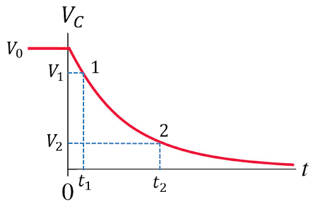

When using your oscilloscope, you will be able to directly measure the voltage at different times throughout the discharging of the capacitor. Consider two different voltages, $V_1$ and $V_2$ measured at times $t_1$ and $t_2$. We can write our exponential decay equation for each of these points,

$$ V_1 = V_0 e^{-t_1/\tau} $$ $$ V_2 = V_0 e^{-t_2/\tau} .$$

Using some algebra and the rules for natural logarithms and exponentials below, demonstrate on your own that we can express $\tau$ as

$$ \tau = \frac{t_2 - t_1}{\ln (V_1/V_2)}.$$

**Your turn #1:** Grab a piece of paper and take a moment to show that you can express the time constant ($\tau$) in the format shown.

Here are some rules for natural logarithms and exponentials that may be of use:

1. Inverse properties: $\ln (e^x) = x$ and $e^{\ln x} = x$
2. Sum (logs): $\ln (x) + \ln (y) = \ln (xy)$
3. Difference (logs): $\ln (x) - \ln (y) = \ln (x/y)$
4. Product (exponentials): $e^x e^y = e^{x+y}$
5. Quotient (exponentials): $e^x/e^y = e^{x-y}$

##### **Uncollapse to see a derivation of $\tau$ if you are having trouble on your own**

As explained above, the voltage decay as viewed on the oscilloscope will follow

$$ V_C(t\geq 0) = V_0 e^{-t/\tau} .$$

Note that for $t<0$ we have $V_C=V_0$, since the switch hasn't been closed yet. If we now measure two points on the curve, they are given by

$$ V_1 = V_0 e^{-t_1/\tau} $$ $$ V_2 = V_0 e^{-t_2/\tau} .$$

Dividing these two equations gives us

$$ \frac{V_1}{V_2} = \frac{V_0 e^{-t_1/\tau}}{V_0 e^{-t_2/\tau}}. $$

Note that the $V_0$'s cancel out, and by property 5 of exponentials and logarithms given above we can simplify

$$ \frac{V_1}{V_2} = \frac{e^{-t_1/\tau}}{e^{-t_2/\tau}} = \exp \left[-\frac{t_1}{\tau} - \left(-\frac{t_2}{\tau}\right) \right] = \exp\left[\frac{-t_1 + t_2}{\tau} \right] = e^{(t_2-t_1)/\tau}.$$

To isolate $\tau$ we need to take the logarithm of both sides to "undo" the exponentiation (property 1)

$$ \ln (V_1/V_2) = \ln \left(e^{(t_2-t_1)/\tau}\right) = \frac{t_2-t_1}{\tau} .$$

Now we just need to rearrange the above equation for $\tau$ and we arrive at the answer given

$$ \tau = \frac{t_2-t_1}{\ln (V_1/V_2)}. $$

Note that this worked without specifying a specific set of two points on the decay curve, meaning you can choose any two points on the curve to estimate $\tau$. You will verify this in the following section.

## Building your spreadsheet and collecting some sample data

The cell below will generate a blank spreadsheet to store some prelab data. Later you can adapt in the actual lab to store your real measurements from the oscilloscope. Run the cell below and add enough columns to store data for Method 1, meaning you'll be setting resistance ($R$) and measuring $V_1$, $t_1$, $V_2$, $t_2$. (Don't forget uncertainty for each variable!)

```python
# Run me to create an initial data entry sheet

de1 = data_entry2.sheet("prelab07_data")
```

```
Sheet name: prelab07_data.csv
```

Below is a simulated decay curve from a circuit set up with the following settings:

- $V_0 = 2.1 V$
- $R = (2000 \pm 20)\,\Omega$

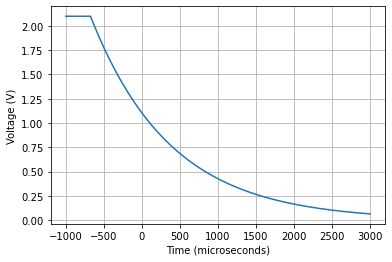

**Your turn #2**:

- Find two points on the curve to measure voltage and time, then enter these values into your spreadsheet above.
- For the purposes of this exercise, use $u\_t = 20\ \mu$s for both time measurements and $u\_V = 0.02\,\text{V}$ for both voltage measurements. In the actual lab you will use appropriate uncertainty estimation techniques to determine the uncertainties for your measurements.
- Once one row of data has been filled out, press "Generate Vectors". The cell below steps you through the calculation of $\tau$; run this cell to see the result. You may also use this code to help you with calculations of $\tau$ in the actual lab.

##### **Uncollapse for an example set of data**

The easiest early point to extract is the one that crosses both grid lines at $t_1$ = -500 $\mu$s, and $V_1$ = 1.75 V.

No other points cross both grid lines. However, the point at $t_2$ = +1000 $\mu$s looks like it is approximately 3/5ths of the way between V = 0.25 V and V = 0.50 V, so we will say $V_2$ = 0.40 V.

If you use these points, you should find that you get tau = 0.00101632 s below

```python
# Run me to calculate the time constant based on your values of t1, t2, V1 and V2

deltat = t2Vec - t1Vec # difference in time between points
W = V1Vec / V2Vec # ratio of voltage
lnW = np.log(W) # taking the logarithm - note that np.log(X) calculates ln(X) in Python

tau = deltat / lnW # calculating the time constant
print("tau =",tau, "s")
```

```
tau = [1432.04118101 1079.18651898 1030.72435901 1174.56911338           nan
 1174.56911338 1501.89472393 1079.18651898 1432.04118101] s
```

**Your turn #3:** Given your calculated $\tau$ and the resistance provided above, what is the capacitance?

```python
# Use this cell to calculate C
C = tau/2000
C
```

```
array([0.71602059, 0.53959326, 0.51536218, 0.58728456,        nan,
       0.58728456, 0.75094736, 0.53959326, 0.71602059])
```

##### **Uncollapse for answer**

The time constant is defined as $\tau = RC$. Since we have calculated $\tau$ and set $R$ initially, we can solve for the capacitance, $C$

$$ C = \frac{\tau}{R} \approx \frac{0.001 s}{2000\Omega} = 5 \times 10^{-7} F = 0.5\ \mu F $$

## Uncertainty propagation to calculate $u[t]$

Now for uncertainty propagation. Recall that in the lab you will be varying $R$ and determining the associated $\tau$ using your measurements of $t_1$, $t_2$, $V_1$ and $V_2$. This will allow you to fit a curve (using chi-squared as a guide) to a $\tau$ vs. $R$ scatter plot. Therefore, we need uncertainty in the y-axis variable: $u\_\tau$.

Looking back at our equation for $\tau$,

$$ \tau = \frac{t_2-t_1}{\ln(V_1/V_2)} $$

we can break down uncertainty propagation into four subproblems to make our lives easier. Often it is good practice to start inwards and work our way outwards in an equation. We can immediately notice the equation involves a subtraction and a division, both of which we have encountered in this course already when it comes to uncertainty propagation.

Let's start with subproblem 1 by defining $\Delta t = t_2 - t_1$. Using the uncertainty propagation formula for addition or subtraction, we have

$$ u\_\Delta t = \sqrt{(u\_t_1)^2 + (u\_t_2)^2} .$$

In the denominator, we encounter subproblem 2, related to $W = V_1/V_2$. Using the uncertainty propagation formula for multiplication or division, we arrive at

$$ u\_W = W \sqrt{\left(\frac{u\_V_1}{V_1}\right)^2 + \left(\frac{u\_V_2}{V_2}\right)^2}. $$

Subproblem 3 involves a logarithm, which we haven't encountered before in uncertainty propagation, but it will continue to come up again in future labs. Our most general equation for uncertainty propagation uses derivatives

$$ u\_R(x_1, x_2, \cdots , x_N) = \sqrt{\sum_{i=1}^N \left(u\_x_i \frac{\partial R}{\partial x_i}\right)^2}. $$

We will use the function $R(x) = \ln x$. Since this depends on only one variable, $x$, our equation above simplifies greatly

$$ u\_R(x) = \left|u\_x \frac{dR}{dx}\right| .$$

Since the derivative of $\ln x$, with respect to $x$, is $1/x$, we can write $u\_R$ as

$$ u\_R(x) = u\_x\cdot \frac{d}{dx} \ln x = \frac{u\_x}{x}. $$

In our specific subproblem we are taking the logarithm of $W$, so we have

$$ u\_\ln(W) = \frac{u\_W}{W} .$$

Stepping back for a moment, we have simplified our initial equation for $\tau$ as

$$ \tau = \frac{t_2-t_1}{\ln(V_1/V_2)} = \frac{\Delta t}{\ln W} .$$

In subproblems 1-3 we have arrived at equations for $u\_\Delta t$ and $u\_\ln W$.

Subproblem 4 is yet another division

$$ u\_\tau = u\left[\frac{\Delta t}{\ln W}\right],$$

$$ u\_\tau = \tau \sqrt{\left(\frac{u\_\Delta t}{\Delta t}\right)^2 + \left(\frac{u\_\ln W}{\ln W}\right)^2}. $$

**Your turn #4:**

- In the cell below we have provided the correct code to implement subproblems 1 and 2
- We have also provided the variables needed for subproblems 3 and 4, but you will need to build the correct equation using these variables.
- Once you have completed the cell, run it to obtain a value for $u\_\tau$. You may use this code to perform your uncertainty propagation during the actual lab.

```python
# Use this cell to complete the python code for subproblems 3 and 4.

# Subproblem 1: propagation of u[deltaT]
udeltat = np.sqrt( ut1Vec**2 + ut2Vec**2 )

# Subproblem 2: propagation of u[W]
# - Recall that W was defined in an earlier code cell
uW = W * np.sqrt( (uV1Vec/V1Vec)**2 + (uV2Vec/V2Vec)**2 )

# Subproblem 3: propagation of u[lnW]
ulnW = uW / W  # correct this equation

# subproblem 4: propagation of u[deltaT/lnW] to get u[tau]
utau = tau * np.sqrt( (udeltat / deltat)**2 + (ulnW / lnW)**2)  # correct this equation

print("u[tau] =",utau, "s")
print("tau =",tau, "s")
print("Relative uncertainty u[tau]/tau = ",utau/tau)
```

```
u[tau] = [68.17181093 47.11591798 45.87930108 90.43755633         nan 90.43755633
 63.12961237 47.11591798 68.17181093] s
tau = [1432.04118101 1079.18651898 1030.72435901 1174.56911338           nan
 1174.56911338 1501.89472393 1079.18651898 1432.04118101] s
Relative uncertainty u[tau]/tau =  [0.04760464 0.04365873 0.04451171 0.07699637        nan 0.07699637
 0.04203331 0.04365873 0.04760464]
```

If you used the example data that we extracted earlier, you should find that you get

- u_tau = [4.0182e-05] s
- tau = [0.0010163] s
- Relative uncertainty u_tau/tau = [0.0395]

Our formula for $\tau$ doesn't depend on any specific $(t_1,V_1)$ and $(t_2,V_2)$ chosen, meaning you can pick any two points on the curve to get an estimate of $\tau$! However, since the $(t_1,V_1)$ and $(t_2,V_2)$ chosen enter the equations for calculating $u\_\tau$, it follows that these choices will influence your uncertainty.

**Your turn #5:** Go back now to the simulated decay curve and pick a new second point $(t_2, V_2)$ on the curve that is either much closer to or further away from your first point $(t_2, V_2)$. Replace your original second point into the spreadsheet and re-run the code cells to calculate $\tau$, $u\_\tau$, and relative uncertainty in $\tau$. What do you notice about how the spacing of points affects the quality (relative uncertainty) of your measurements?

Relative uncertainty decreases when we make the mentioned changed. However if t2 is really big then relative uncertainty increases.

##### **Uncollapse for answer**

We use relative uncertainty to evaluate the quality of our measurements. You should find that for points spaced further apart in time, the relative uncertainty decreases, meaning we have more precision and thus a higher quality measurement. However, there are some exceptions! In particular if you make $t_2$ large enough (and $V_2$ small enough), you'll find that the relative uncertainty begins to increase again!

To get more insight into this, you can either consider the equations for the relative uncertainty in more detail, or think carefully about how the flattening of the curve at long times affects the relative uncertainty.

## A review of chi-squared ($\chi^2$)

### Formulation of chi-squared

Last lab we introduced you to a new tool, chi-squared, which indicates the goodness of fit of a model to data, a tool we will continue to use for the remainder of the course.

Chi-squared ($\chi^2$) is closely related to residuals, which we also have been using for the past couple labs. Suppose we have $N$ data points ${y_1, y_2, \cdots , y_N}$ measured by setting the dependent value to ${x_1, x_2, \cdots , x_N}$, respectively, and determine a model fit $f(x_i)$, then the residuals are given by

$$ R(x_i) = y_i - f(x_i) .$$

The residuals tell us how far away our model is from the data. Intuitively, smaller residuals should indicate a better fit. However, we must also consider the measurement uncertainty as well when we look at goodness of fit. Since standard uncertainty corresponds to a 68% confidence interval of where we expect our measurements to fall, we would also expect our residuals to be of a similar magnitude to this 68% confidence interval if *(i) our uncertainty is well estimated* and *(ii) our model is describing the underlying behaviour of the data well*. Mathematically, this could be expressed as

$$ \frac{R(x_i)}{u\_y_i} \approx 1 $$

where $u\_y_i$ is the uncertainty of $y_i$. This can be thought of as a *weighted* residual, since we using the uncertainty to help us gauge whether the distance between our data and model is reasonable.

Since we want to consider all residuals when assessing goodness of fit, chi-squared takes the weighted residuals, squares them, sums them up, then divides by a normalization factor $N-P$, where $N$ is the number of data points and $P$ is the number of parameters in the model:

$$\chi^2 = \frac{1}{N-P} \sum_{i=1}^N \left(\frac{R(x_i)}{u\_y_i}\right)^2 .$$

Just like in the weighted mean, the squaring of the weighted residuals can be thought of as penalizing residuals that are much larger than the uncertainty at that data point, since the ratio $R(x_i)/u\_y_i$ will be large and so $(R(x_i)/u\_y_i)^2$ will be even larger!

The division by $N-P$ serves two purposes:

1. If we didn't divide by something containing $N$, then chi-squared would get bigger and bigger as we added data points.
2. We don't want a model that *overfits*, that is using too many parameters to make a model so complicated that it is guaranteed to fit the data perfectly. A complicated model with a lot of parameters will have a large $P$, which increases $\chi^2$. In other words, a simpler model that describes the data just as well as a more complicated model is better! (Google "Occam's Razor" if you are interested in reading more.)

### Interpreting chi-squared

In an ideal experiment, you would collect as much data as is feasible and have the minimum number of parameters necessary. In this case, $N >> P$ and so $N-P \approx N$, meaning chi-squared reduces to the average of the weighted residuals

$$ \chi^2 \approx \frac{1}{N} \sum_{i=1}^N \left(\frac{R(x_i)}{u\_y_i}\right)^2 , \text{ for } N>>P.$$

We can now go back to our earlier statement that a good fit to data with well estimated uncertainties should have $ \frac{R(x_i)}{u\_y_i} \approx 1 $. If this is true and we have $N>>P$, then

$$ \chi^2 \approx \frac{1}{N} \sum_{i=1}^N \left(\frac{R(x_i)}{u\_y_i}\right)^2 \approx \frac{1}{N} \sum_{i=1}^N 1^2 = \frac{N}{N} = 1.$$

Therefore, for a good fit to data with well estimated uncertainties we expect $\chi^2 \approx 1$. See the data plot and residuals plot below for an example of this scenario, with $\chi^2=0.87$. Although chi-squared indicates a good fit, we can verify that our residuals plot also provides evidence of a good fit. Namely, we expect:

1. There is no trend in the residuals,
2. The residuals are evenly scattered above and below the x-axis, and
3. Roughly 2/3 of the errorbars cross the x-axis.

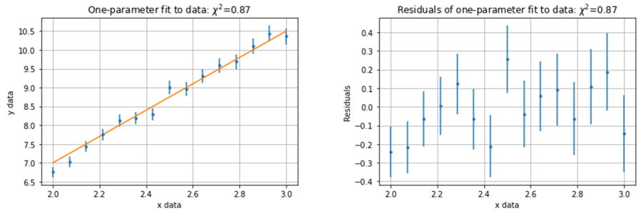

But what if we compute chi-squared and find $\chi^2 >> 1$ or $\chi^2 << 1$? We can take a look at the variables within chi-squared to see what could cause each of these cases.

**$\chi^2 \ll 1$:**

Looking at the sum within the formula for chi-squared, the only way this case can occur is if $R(x_i) \ll u\_y_i$. That is, the residuals are much smaller than the uncertainties. This tells us that our uncertainties are likely *overestimated* and we need to reevaluate how we are estimating uncertainty (or perhaps there is an error in our uncertainty calculations).

See the data plot and residuals plot below for an example where $\chi^2=0.1$ as a result of overestimated uncertainties. While the initial fit to the data with uncertainty looks reasonable, when we zoom in using the residuals plot we see that all error bars are crossing the x-axis. Since the error bars represent a 68% confidence interval, there should be a 68% probability (roughly 2/3) that the error bar covers the distance between the data and the model or, equivalently, a 68% chance the error bar overlaps with the x-axis in the residuals plot.

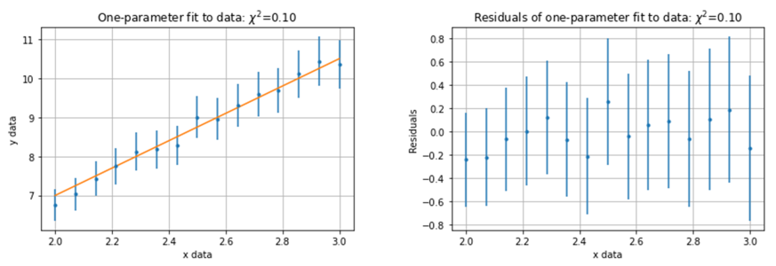

**$\chi^2 \gg 1$:**

This could potentially indicate the opposite problem as above: our uncertainties are *underestimated* such that the demonimator in the sum of chi-squared, the uncertainty, is much smaller than the numerator, the residuals. Again we would want to reevaluate how we are estimating uncertainties. See the example plots below where $\chi^2=10.5$ as a result of underestimated uncertainties. Even from the data plot it is obvious that the error bars look too small based on the scatter of the data about the fit, but the residuals plot makes it even more clear that the uncertainties are underestimated, with very few error bars crossing the x-axis.

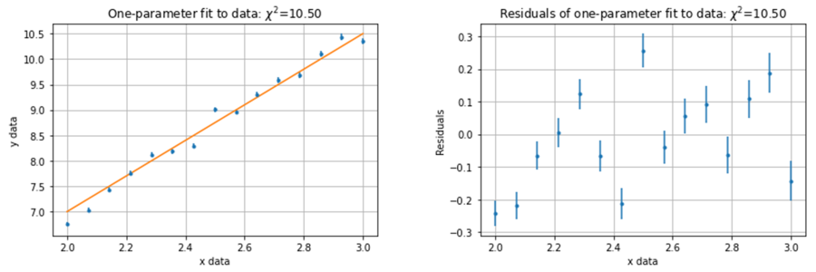

Another way we could have $\chi^2\gg1$ is that the fit is simply not good! If this is the case, we would need to look at the residuals plot for evidence of a poor fit. The fit might not be good for a couple of reasons: the parameters might not be adjusted optimally, or the fitting function might not be capable of fitting the data.

**Your turn #6:** Look at the two sets of example plots below, both having $\chi^2\gg1$, and use the residuals plot to determine why the fit is poor. What should be done to the fit in each case to improve the goodness of fit?

6.1

- We can see that the residuals are in a decreasing trend so the slope is too high.

6.2

- Model is below the data points on scatter plot so we know that the slope is correct but the y-intercept is calculated incorrectly.

##### **Uncollapse for answers**

For 6.1, the slope is a bit too high which you can tell from the scatter plot or the residuals trending downward with a somewhat linear shape. But since our x-values start at 2.0, you will also find that you need to update the y-intercept as well.

For 6.2, the y-intercept is too low, which you can see from the scatter plot where the model is typically below the data points, or similarly from the resisuals plot where the residuals (data - model) are almost all positive.

##### Example plots 6.1

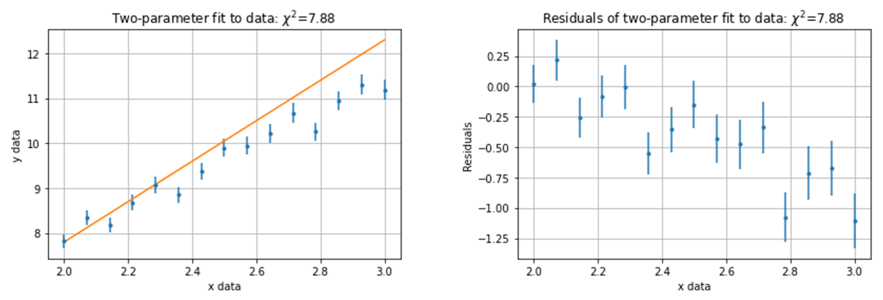

##### Example plots 6.2

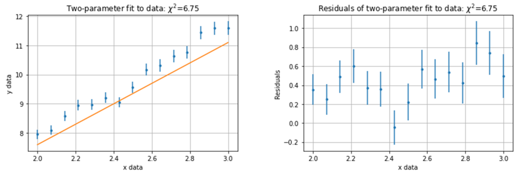

Some final cautions:

- First: we should only be interpreting chi-squared **after it is minimized**. This means we first find the best possible fit of this model to these data and then ask chi-squared what it can tell us about the overall quality of this best possible fit.
- Second: it is possible that the effects of overestimated uncertainties and a poor fit can combine to give you a misleading chi-squared, as in the example below. Unfortunately, the effect of a higher chi-squared from the bad fit cancels with the effect of a lower chi-squared from overestimated uncertainties, yielding $\chi^2=1.09$ despite the model being a poor fit to the data. Therefore, **it is extremely important that you consult the residuals plot when interpreting chi-squared**. The take-home message should be that chi-squared and residuals together will give you the full story when it comes to goodness of fit; if we only calculated chi-squared in the scenario below we might think we have a good fit, but upon inspection of the residuals we would notice the trend in the residuals and conclude the fit is poor.

##### An example of a poor fit combined with overestimated uncertainties

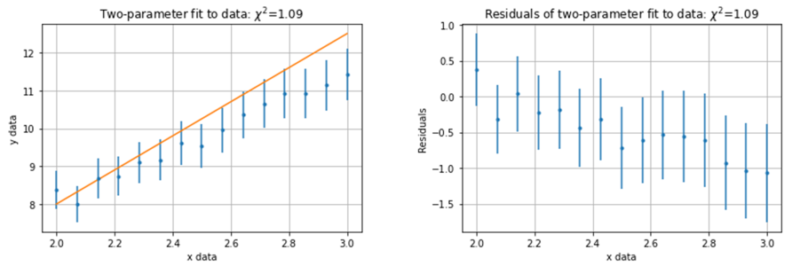

Please turn in an HTML version of this notebook as you've done before.